# Sea Shanties are socio-technical systems too, see

(When viewing from mobile, swipe left to see the “footnotes” in the right-hand margin)

# Oh no dude, everything is a socio-technical system to you!

Well, yes. Everything *is* a socio-technical system to me, yes. But not all systems are created and evolved equally. TikTok, for example, is to my mind a social media company that sits in the (auspicious) category of Twitter. The only one since Twitter to shift the needle, really. Snap, Insta etc were all just pretenders to the throne. Tik-tok is an entirely different beast, with an architecture that deserves it’s own digital gardening note.

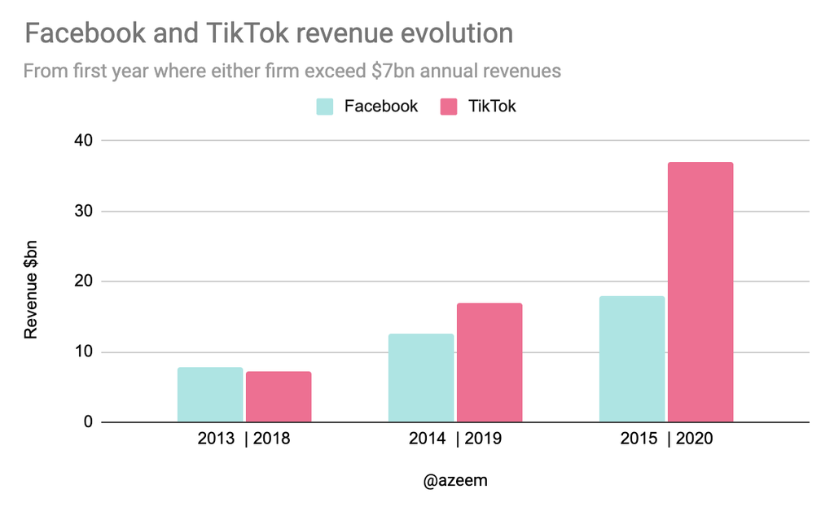

Figure 1: Azeem, Exponential View

TikTok apparently cracked $35bn in revenue in 2020, which is off-the-chart. For context, Facebook revenue is *only* double that at around $70bn. See this chart in the margin from [Azeem at Exponential View.](https://www.exponentialview.co/p/ev-307)

TikTok is, for many reasons, a truly global cultural force. But as far as a socio-technical systems goes, it’s right there at the vanguard of new, interesting, exciting and scary socio-technical systems. In a post that I’ve referenced a dozen times in the last while, [Eugene Wei dives into TikTok](https://www.eugenewei.com/blog/2020/8/3/tiktok-and-the-sorting-hat?s=09) in a piercingly insightful way.

> “It turns out that in some categories, a machine learning algorithm significantly responsive and accurate can pierce the veil of cultural ignorance. Today, sometimes culture can be abstracted.”

> — Eugene Wei

Wei’s piece is really worth reading in full (a few times). In essence, we have here an algorithm that seems (if you accept Wei’s thesis on the “veil of cultural ignorance”) to have tackled a cultural problem, and succeeded wildly. I’m persuaded by Wei’s thesis, and also found some of my mental models jarred by his (almost throw-away) comment on being a “cultural determinist.” In that context, TikTok is a remarkable product/system that weaves together deep technical expertise to capitalise on deep social forces. And in the process, it has become a social (cultural) force in it’s own right.

He writes “My default hypothesis was that what I call the veil of cultural ignorance was too impenetrable a barrier. That companies from non-WEIRD countries (Joseph Henrich shorthand for Western, Educated, Industrialized, Rich, and Democratic) would struggle to ship into WEIRD cultures. I was even skeptical of the reverse, of U.S. companies competing in China or India. The further the cultural distance between two countries, the more challenging it would be for companies in one to compete in the other.”

TikTok truly is something special, something I’m in the process of slowly understanding, but this Digital Garden note was meant to be about sea-shanties.

# Soon may the Wellerman come

If you don’t know who the Wellerman is, well, OK. It’s OK, but I fear you may be missing out on the best the internet has to offer. I’ve thoroughly enjoyed the #seashantytok, and here’s [a NYT primer](https://www.nytimes.com/2021/01/13/style/sea-shanty-tiktok-wellerman.html) to catch you up if needed.

Sea Shanties, it turns out, have some of their roots in the coordination of shipping tasks, somewhere back in the 18th century. Wikipedia [provides an instructive example](https://en.wikipedia.org/wiki/Sea_shanty#Nature_of_the_songs) from a marine book seemingly published in 1784!

> “It requires, however, some dexterity and address to manage the handspec to the greatest advantage; and to perform this the sailors must all rise at once upon the windlass, and, fixing their bars therein, give a sudden jerk at the same instant, in which movement they are regulated by a sort of song or howl pronounced by one of their number..”

> — Falconer, William, An Universal Dictionary of the Marine, New Edition, T. Cadell (1784)., Via Wikipedia

It’s this use of a song/chant to coordinate labour in a technical setting that makes shanties an interesting socio-technical system to me. (There’s also the link between shanties and slavery, which I’ll hopefully remember to address a little later).

There is, of course, nuance here. Wellerman itself may not be shanty at all, and rather a ballad with a shanty tune. See the NYT piece for more. While I’m a fan of nuance, generally speaking, but it can inhibit the development of good theory. See Kieran Healy’s piece [“Fuck Nuance” here.](https://kieranhealy.org/files/papers/fuck-nuance.pdf)

The link between technical labour and social coordination allows me to draw very clear links between the “socio” and the “technical” in this instance. Shanties have, almost by definition, the feature of a cadence that enables singing. Coffin, the expert interviewed by the NYT, has a nice quote on shanties: " “That’s one of the things I love about sea shanties,” he added. “The accessibility. You don’t have to be a trained singer to sing on it. You’re not supposed to sing pretty.” "

The Wikipedia page on sea-shanty’s notes that “The shanty genre was typified by flexible lyrical forms, which in practice provided for much improvisation and the ability to lengthen or shorten a song to match the circumstances.” The circumstances referred to in this quote are, presumably, related to the task at hand, which in turn is linked directly to the technicalities of sailing.

For example, a change in length, or maybe weight, of a component on the windlass referred to in the example above, might lead to a change in timing in the task required. Which, in turn, would force in a change in the governing sea-shanty. The cadence of the sea-shanty would have to respond to a the technical change.

I’m using the word “cadence” here with the reckless abandon of “fool on the internet with strong view” and no doubt people who know anything really about music would cringe at this improper use of the term. A rudimentary search reveals all manner of complexity related to the idea - there is for example tonality and cadence and harmony and pitches and chords and other such concepts way beyond my comprehension.

A [technical term](https://hal.archives-ouvertes.fr/hal-01801060/document) which seems to refer to “any musical element or combination of musical elements, including silence, that indicates relative relaxation or relative con-clusion in music”

I do think it’s safe to say however, that cadence (in my usage) can be “mapped” and understood sufficiently such that one song could be said to have a “quick/high/big/insert adjective” cadence where another a “slow/low/small” cadence.

There is then, a relationship between L (the length of the hypothetical component on the windlass) and cadence C of the sea-shanty being sung to co-ordinate the task involving the windlass.

I like this neat mapping of L to C, even though such neatness may only be attractive to me.

# So what?

Other than there being a neat relationship between the social (C) and the technical (L), which is immediately satisfying, I think there are other broader-theme “so whats.”

For starters, the ability to describe and analyze music and songs almost mathematically yields all types of opportunity and threats. One among them is that perhaps (I’m not sure this is entirely true, but it’s a fair argument) music, particularly within genres, [is starting to sound the same](https://www.theguardian.com/music/2012/jul/27/pop-music-sounds-same-survey-reveals). This probably has something to do with the algorithms of Spotify and TikTok, which takes me back to Wei’s piece I cited earlier: if the algorithm has figured out culture, what does that mean for culture?

I suppose there are a long list of interesting pieces on this question, which I’ll scour around for on another day.

Another implication: sea-shantys clearly have played an important role in fostering a sense of community. They have roots in the slave trade, and can be linked to Caribbean slave songs. Traditional slave songs, in the Caribbean in turn played an important role in rebellion. What now of online communities? What are the online equivalent of sea-shanties for a distributed “remote-first” work force? While the majority of the work force is still largely an in-person, “manual-labour” world, and I’m by no means diminishing that, the world of work is inevitably changing. Sea-shanties were made redundant by steam-powered ships, and tech will come eventually for most forms of labour that can be mechanized.

In a incredibly well written and intricately researched piece for LRB, [Pooja Bhatia](https://twitter.com/bhatiap) writes “It isn’t a coincidence that British sea shanties ‘bear striking resemblances to Caribbean slave songs’. Indeed, the ‘very practice of shantying may have its roots in the interaction of sailors and black dockworkers.’”

A less dark implication for the workforce: practically speaking, sea-shanties solved coordination problems. How do online communities, particularly companies with an [asynchronous working culture](https://about.gitlab.com/company/culture/all-remote/asynchronous/), solve simliar coordination problems? Are their even time sensitive online tasks done by multiple people in some coordination?

What socio-technical system, if any, replaces the sea-shanty?

And in closing, the original SeaShanty TikTok:

> @nathanevanss

> The Wellerman. [#seashanty](https://www.tiktok.com/tag/seashanty) [#sea](https://www.tiktok.com/tag/sea) [#shanty](https://www.tiktok.com/tag/shanty) [#viral](https://www.tiktok.com/tag/viral) [#singing](https://www.tiktok.com/tag/singing) [#acoustic](https://www.tiktok.com/tag/acoustic) [#pirate](https://www.tiktok.com/tag/pirate) [#new](https://www.tiktok.com/tag/new) [#original](https://www.tiktok.com/tag/original) [#fyp](https://www.tiktok.com/tag/fyp) [#foryou](https://www.tiktok.com/tag/foryou) [#foryoupage](https://www.tiktok.com/tag/foryoupage) [#singer](https://www.tiktok.com/tag/singer) [#scottishsinger](https://www.tiktok.com/tag/scottishsinger) [#scottish](https://www.tiktok.com/tag/scottish)

> [♬ original sound - N A T H A N E V A N S S](https://www.tiktok.com/music/original-sound-6910995343458962177)

# Bibliography

Bhatia, Pooja. 2020. ‘The End of the Plantocracy’. London Review of Books, 19 November 2020. https://www.lrb.co.uk/the-paper/v42/n22/pooja-bhatia/the-end-of-the-plantocracy. ‘Bigo et al. - Relevance of Musical Features for Cadence Detectio.Pdf’. n.d. Accessed 31 January 2021. https://hal.archives-ouvertes.fr/hal-01801060/document. Bigo, Louis, Laurent Feisthauer, Mathieu Giraud, and Florence Levé. n.d. ‘Relevance of Musical Features for Cadence Detection’, 8. ‘Embracing Asynchronous Communication’. n.d. GitLab. Accessed 31 January 2021. https://about.gitlab.com/company/culture/all-remote/asynchronous/. ‘Fuck-Nuance.Pdf’. n.d. Accessed 31 January 2021. https://kieranhealy.org/files/papers/fuck-nuance.pdf. ‘Pooja Bhatia (@bhatiap) / Twitter’. n.d. Twitter. Accessed 31 January 2021. https://twitter.com/bhatiap. ‘Pop Music These Days: It All Sounds the Same, Survey Reveals’. 2012. The Guardian. 27 July 2012. http://www.theguardian.com/music/2012/jul/27/pop-music-sounds-same-survey-reveals. Renner, Rebecca. 2021. ‘Everyone’s Singing Sea Shanties (or Are They Whaling Songs?)’. The New York Times, 13 January 2021, sec. Style. https://www.nytimes.com/2021/01/13/style/sea-shanty-tiktok-wellerman.html. ‘Sea Shanty’. 2021. In Wikipedia. https://en.wikipedia.org/w/index.php?title=Sea_shanty&oldid=1002896506. ‘TikTok and the Sorting Hat’. n.d. Remains of the Day. Accessed 31 January 2021. https://www.eugenewei.com/blog/2020/8/3/tiktok-and-the-sorting-hat. ‘Tonality’. 2021. In Wikipedia. https://en.wikipedia.org/w/index.php?title=Tonality&oldid=1000011557.